# The T20 Impact Index

Separating the Anchors from the Enforcers: a data autopsy in R to settle the GOAT debate

Author

Pratik Patil | Analysis Before Wicket

Published

4 November 2026

## Introduction

Who is the greatest T20 batter of all time? Fans argue with their hearts, often pointing to raw run totals or highlight-reel sixes. As data scientists, we wanted to settle the debate mathematically.

To find the true GOAT, we built a **Composite Impact Score**. It is designed to penalise slow, outdated anchors and reckless sloggers, and to reward only those who maximise *both* consistency and aggression.

$$\text{Impact Score} = \frac{\text{Batting Average} \times \text{Strike Rate}}{100}$$

**Fair fight rules.** To keep weak opposition from skewing the numbers, we analyse only players from Full Member Test-playing nations with **at least 50 T20I innings**.

## Fetching & Cleaning the Data

We pull career T20I batting data with the `cricketdata` package. The raw download is saved next to this file (`t20_career_batting.rds`), so re-rendering is instant and works offline. Delete that file to fetch fresh numbers.

```r
library(cricketdata)
library(tidyverse)
library(ggrepel)
library(scales)

cache_file <- "t20_career_batting.rds"
if (file.exists(cache_file)) {
  raw <- readRDS(cache_file)
} else {
  raw <- fetch_cricinfo(matchtype = "t20", sex = "men",
                        activity = "batting", type = "career")
  saveRDS(raw, cache_file)
}

# Be tolerant of older column names, then fail early with a clear message
raw <- raw %>% rename(any_of(c(Average = "Ave", StrikeRate = "SR")))
required <- c("Player", "Country", "Innings", "NotOuts", "Runs",
              "Average", "StrikeRate", "Fours", "Sixes")
absent <- setdiff(required, names(raw))
if (length(absent)) stop("cricketdata is missing columns: ", paste(absent, collapse = ", "), call. = FALSE)

# Full Member nations (full names or the short codes Cricinfo sometimes uses).
# Multi-country players such as "Eng/Ire" match too.
full_member <- regex(
  paste0("\\b(India|Ind|Australia|Aus|England|Eng|Pakistan|Pak|South Africa|SA|",
         "New Zealand|NZ|Sri Lanka|SL|West Indies|WI|Bangladesh|Ban|",
         "Afghanistan|Afg|Zimbabwe|Zim|Ireland|Ire)\\b"),
  ignore_case = TRUE
)

clean_data <- raw %>%
  filter(str_detect(Country, full_member), Innings >= 50) %>%
  filter(!is.na(Fours), !is.na(Sixes)) %>%          # missing is not the same as zero
  mutate(
    NotOuts       = coalesce(NotOuts, 0),
    Boundary_Runs = Fours * 4 + Sixes * 6,
    Boundary_Pct  = Boundary_Runs / Runs * 100,     # share of runs from 4s and 6s
    Impact_Score  = Average * StrikeRate / 100,     # the Impact Score
    NotOut_Pct    = NotOuts / Innings * 100         # finishing ability
  ) %>%
  filter(Boundary_Pct <= 100, !is.na(Impact_Score))  # drop impossible rows
```

```r
# A dark, saffron-accented ggplot theme shared by every chart
pal <- list(saffron = "#FF9933", amber = "#FFB347", deep = "#FF6A00", teal = "#2dd4bf",
            bg = "#11151c", ink = "#e6edf3", muted = "#8b949e", grid = "#222a35")

theme_saffron <- function(base_size = 13) {
  theme_minimal(base_size = base_size) +
    theme(
      plot.background   = element_rect(fill = pal$bg, colour = NA),
      panel.background  = element_rect(fill = pal$bg, colour = NA),
      panel.grid.major  = element_line(colour = pal$grid, linewidth = 0.4),
      panel.grid.minor  = element_blank(),
      text              = element_text(colour = pal$ink),
      axis.text         = element_text(colour = pal$ink),
      axis.title        = element_text(colour = pal$muted, face = "bold", size = base_size - 2),
      plot.title        = element_text(colour = pal$saffron, face = "bold", size = base_size + 5,
                                       hjust = 0, margin = margin(b = 4)),
      plot.subtitle     = element_text(colour = pal$muted, size = base_size - 1.5,
                                       hjust = 0, margin = margin(b = 14)),
      plot.caption      = element_text(colour = pal$muted, size = base_size - 4,
                                       hjust = 1, margin = margin(t = 12)),
      plot.title.position   = "plot",
      plot.caption.position = "plot",
      legend.title      = element_text(colour = pal$muted, size = base_size - 3),
      legend.text       = element_text(colour = pal$ink, size = base_size - 3),
      plot.margin       = margin(18, 22, 14, 18)
    )
}
theme_set(theme_saffron())

cap <- "Data: ESPNcricinfo via {cricketdata} | Min. 50 innings, Full Member nations | Analysis Before Wicket"
```

```r
# Everything the narrative below quotes comes from here, so the text can never drift from the charts
goat      <- slice_max(clean_data, Impact_Score, n = 1,  with_ties = FALSE)
top_15    <- slice_max(clean_data, Impact_Score, n = 15, with_ties = FALSE)
finisher  <- slice_max(top_15, NotOut_Pct, n = 1, with_ties = FALSE)

top_40 <- slice_max(clean_data, Impact_Score, n = 40, with_ties = FALSE)
mx <- mean(top_40$Boundary_Pct)
my <- mean(top_40$Impact_Score)
top_40 <- top_40 %>%
  mutate(Camp = case_when(
    Impact_Score >= my & Boundary_Pct >= mx ~ "Elite Enforcer",
    Impact_Score >= my                      ~ "Elite Anchor",
    TRUE                                    ~ "Chasing pack"))
anchor   <- top_40 %>% filter(Camp == "Elite Anchor")   %>% slice_max(Impact_Score, n = 1, with_ties = FALSE)
enforcer <- top_40 %>% filter(Camp == "Elite Enforcer") %>% slice_max(Impact_Score, n = 1, with_ties = FALSE)

fastest      <- slice_max(clean_data, StrikeRate,   n = 1,  with_ties = FALSE)
top_boundary <- slice_max(clean_data, Boundary_Pct, n = 10, with_ties = FALSE)
med_boundary <- median(clean_data$Boundary_Pct)
```

## At a Glance

Batters analysed

152

50+ T20I innings

Top Impact Score

66.7

V Kohli

Peak strike rate

196.4

Abhishek Sharma

Boundary-heaviest

80%

Abhishek Sharma

The top ten, ranked by Impact Score:

```r
clean_data %>%
  slice_max(Impact_Score, n = 10, with_ties = FALSE) %>%
  transmute(
    `#`          = row_number(),
    Player, Country,
    Inns         = Innings,
    Runs         = comma(Runs),
    Avg          = sprintf("%.1f", Average),
    SR           = sprintf("%.1f", StrikeRate),
    `Not-out %`  = sprintf("%.0f%%", NotOut_Pct),
    Impact       = sprintf("%.2f", Impact_Score)
  ) %>%
  knitr::kable(format = "html", table.attr = 'class="lb"', align = "rllrrrrrr")
```

| # | Player | Country | Inns | Runs | Avg | SR | Not-out % | Impact |
| --- | --- | --- | --- | --- | --- | --- | --- | --- |
| 1 | V Kohli | India | 117 | 4,188 | 48.7 | 137.0 | 26% | 66.74 |
| 2 | Abhishek Sharma | India | 71 | 2,268 | 32.9 | 196.4 | 3% | 64.54 |
| 3 | NT Tilak Varma | India | 71 | 1,940 | 43.1 | 145.8 | 37% | 62.84 |
| 4 | HC Brook | England | 62 | 1,702 | 36.2 | 164.9 | 24% | 59.72 |
| 5 | Mohammad Rizwan | Pakistan | 93 | 3,414 | 47.4 | 125.4 | 23% | 59.45 |
| 6 | SA Yadav | India | 107 | 3,272 | 36.4 | 162.9 | 16% | 59.24 |
| 7 | TH David | Australia/SGP | 63 | 1,679 | 35.0 | 168.4 | 24% | 58.91 |
| 8 | PD Salt | England | 60 | 1,852 | 34.9 | 163.7 | 12% | 57.22 |
| 9 | KL Rahul | India | 68 | 2,265 | 37.8 | 139.1 | 12% | 52.52 |
| 10 | JC Buttler | England | 150 | 4,384 | 34.8 | 150.1 | 16% | 52.24 |

## 1. The Ultimate Impact Index

Here are the top 15 players by Impact Score. The **brightness of each bar** shows their **Finishing Ability**: the percentage of innings they ended not out.

[figure not shown]

Figure 1: Top 15 T20I batters by Impact Score

```r
ggplot(top_15, aes(x = fct_reorder(Player, Impact_Score), y = Impact_Score, fill = NotOut_Pct)) +
  geom_col(width = 0.72) +
  geom_text(aes(label = sprintf("%.1f", Impact_Score)),
            hjust = -0.25, size = 4, fontface = "bold", colour = pal$ink) +
  coord_flip() +
  scale_fill_gradient(low = "#8a5a22", high = pal$amber, name = "Finishing ability\n(not-out %)") +
  scale_y_continuous(expand = expansion(mult = c(0, 0.12))) +
  labs(title = "The Ultimate T20I Impact Index",
       subtitle = "Impact = (Batting Average x Strike Rate) / 100  |  Top 15",
       x = NULL, y = "Impact Score", caption = cap) +
  theme(panel.grid.major.y = element_blank(),
        axis.text.y = element_text(face = "bold", size = 12))
```

**The Verdict:** the mathematical champion is **V Kohli** (India), with an Impact Score of **66.7**. Notice the difference in style among the top 15: some reach their score through explosive hitting, while the brightest bar belongs to **NT Tilak Varma** , who finished not out in 37% of his innings.

## 2. The Anatomy of a T20 Batter

To see *how* players earn their Impact Scores, we plot **Average** (consistency) against **Strike Rate** (aggression). Bubble size is career runs, and colour is **Boundary Dependency**, from teal (rotates the strike) to saffron (lives off 4s and 6s). The dashed curves are lines of equal Impact Score.

[figure not shown]

Figure 2: Batting average versus strike rate

```r
xr <- range(clean_data$Average)    + c(-2, 2)
yr <- range(clean_data$StrikeRate) + c(-3, 3)

# Lines of equal Impact Score: StrikeRate = 100 * k / Average
iso <- expand_grid(k = c(40, 50, 60), Average = seq(xr[1], xr[2], length.out = 300)) %>%
  mutate(StrikeRate = 100 * k / Average) %>%
  filter(StrikeRate >= yr[1], StrikeRate <= yr[2])
iso_lab <- iso %>% group_by(k) %>% slice_max(Average, n = 1) %>% ungroup()

ggplot(clean_data, aes(x = Average, y = StrikeRate)) +
  geom_line(data = iso, aes(group = k), colour = "#3b4452", linetype = "dashed", linewidth = 0.5) +
  geom_text(data = iso_lab, aes(label = paste("Impact", k)),
            colour = "#6e7681", size = 3, hjust = 1, vjust = -0.6, fontface = "italic") +
  geom_point(aes(size = Runs, fill = Boundary_Pct),
             shape = 21, colour = pal$bg, stroke = 0.5, alpha = 0.92) +
  geom_text_repel(data = slice_max(clean_data, Impact_Score, n = 12, with_ties = FALSE),
                  aes(label = Player), colour = pal$ink, size = 3.4, fontface = "bold",
                  segment.colour = "#3b4452", box.padding = 0.5, min.segment.length = 0,
                  max.overlaps = Inf, seed = 7) +
  scale_fill_gradient(low = pal$teal, high = pal$saffron, name = "Boundary\ndependency (%)") +
  scale_size_continuous(range = c(2.5, 9), guide = "none") +
  coord_cartesian(xlim = xr, ylim = yr) +
  labs(title = "The Anatomy of a T20 Batter",
       subtitle = "Average vs Strike Rate  |  bubble size = career runs",
       x = "Batting average (consistency)", y = "Strike rate (aggression)", caption = cap)
```

**Reading the chart:** the **top-right** is where the elite live, with a high average *and* a high strike rate. The **bottom-right** holds the classic anchors, who are consistent but at a slower tempo. The **top-left** holds the hitters who go big but are dismissed more often.

## 3. The Elite Quadrant

Now isolate the top 40 and map Impact Score against Boundary Dependency. The dashed lines mark the averages of this elite group.

[figure not shown]

Figure 3: The elite quadrant: impact versus boundary dependency

```r
ggplot(top_40, aes(x = Boundary_Pct, y = Impact_Score)) +
  annotate("rect", xmin = -Inf, xmax = mx, ymin = my, ymax = Inf, fill = pal$teal,    alpha = 0.06) +
  annotate("rect", xmin = mx,   xmax = Inf, ymin = my, ymax = Inf, fill = pal$saffron, alpha = 0.06) +
  geom_vline(xintercept = mx, linetype = "dashed", colour = "#4a5361") +
  geom_hline(yintercept = my, linetype = "dashed", colour = "#4a5361") +
  annotate("text", x = -Inf, y = Inf, label = "ELITE ANCHORS",   hjust = -0.1, vjust = 1.7,
           colour = pal$teal,    fontface = "bold", size = 4.2) +
  annotate("text", x = Inf,  y = Inf, label = "ELITE ENFORCERS", hjust = 1.1,  vjust = 1.7,
           colour = pal$saffron, fontface = "bold", size = 4.2) +
  geom_point(aes(colour = Camp), size = 4.5, alpha = 0.95) +
  geom_text_repel(aes(label = Player), colour = pal$ink, size = 3.2, fontface = "bold",
                  segment.colour = "#3b4452", box.padding = 0.35, max.overlaps = Inf, seed = 7) +
  scale_colour_manual(values = c("Elite Enforcer" = pal$saffron,
                                 "Elite Anchor"   = pal$teal,
                                 "Chasing pack"   = "#6e7681"), name = NULL) +
  labs(title = "The Elite Quadrant",
       subtitle = "Top 40 by Impact Score  |  top-left: anchors, top-right: enforcers",
       x = "Boundary dependency (% of runs from 4s and 6s)", y = "Composite Impact Score",
       caption = cap) +
  theme(legend.position = "top", legend.justification = "left")
```

**The Takeaway:** the top of the chart is where GOATs live, and there are **two ways to get there**. The anchors, led by **V Kohli** (Impact 66.7), earn their score through volume and consistency. The enforcers, led by **Abhishek Sharma** (Impact 64.5), earn it through boundary power.

## 4. The Pure Enforcers

Finally, the players who score the highest share of their runs purely through 4s and 6s. The dashed line is the median batter in our sample.

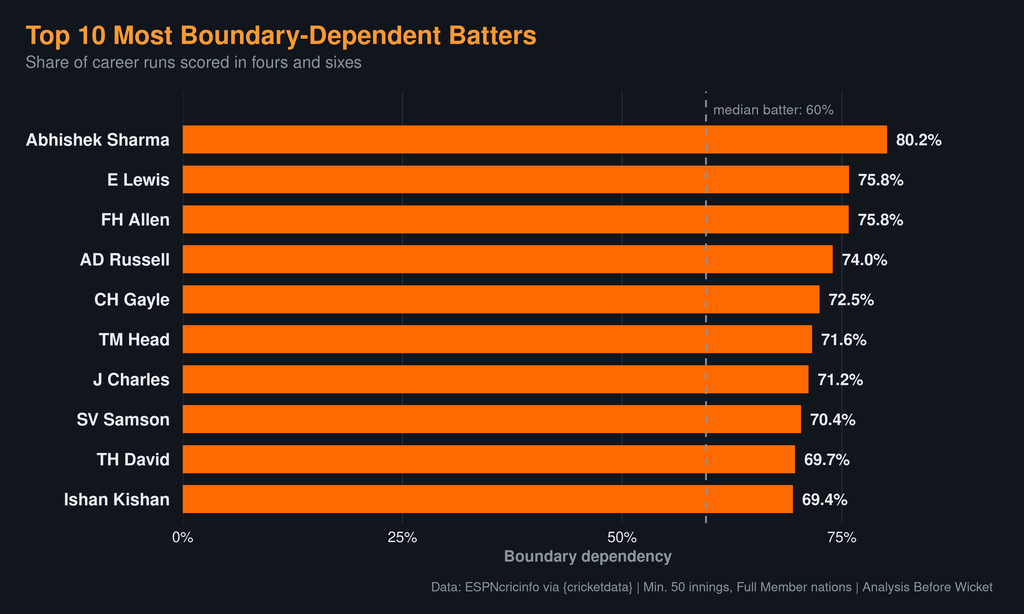

Figure 4: Most boundary-dependent batters

```r
ggplot(top_boundary, aes(x = fct_reorder(Player, Boundary_Pct), y = Boundary_Pct)) +
  geom_col(fill = pal$deep, width = 0.7) +
  geom_hline(yintercept = med_boundary, linetype = "dashed", colour = pal$muted) +
  annotate("text", x = 10.75, y = med_boundary, hjust = -0.06, colour = pal$muted, size = 3.4,
           label = sprintf("median batter: %.0f%%", med_boundary)) +
  geom_text(aes(label = sprintf("%.1f%%", Boundary_Pct)),
            hjust = -0.2, size = 4, fontface = "bold", colour = pal$ink) +
  coord_flip() +
  scale_x_discrete(expand = expansion(add = c(0.6, 1.2))) +   # headroom for the median label
  scale_y_continuous(expand = expansion(mult = c(0, 0.15)), labels = label_percent(scale = 1, accuracy = 1)) +
  labs(title = "Top 10 Most Boundary-Dependent Batters",
       subtitle = "Share of career runs scored in fours and sixes",
       x = NULL, y = "Boundary dependency", caption = cap) +
  theme(panel.grid.major.y = element_blank(),
        axis.text.y = element_text(face = "bold", size = 12))
```

## Conclusion

The data says the T20 GOAT debate is a fork in the road, and **V Kohli** sits at the top of the Impact Index. If you value pure consistency and finishing games, the elite anchors like **V Kohli** are your answer. If you want pure firepower, the explosive camp is led by **Abhishek Sharma** , and the most boundary-reliant batter in the sample is **Abhishek Sharma** , who scores 80% of his runs in fours and sixes.

One thing is certain: if you can’t balance your Average and Strike Rate, you won’t survive at the top of the Impact Index.

**NoteMethod notes and limits**

- **Impact Score** is a simple product, `Average x Strike Rate / 100`. It does not adjust for era, pitch, batting position or opposition quality.
- **Not-outs** inflate averages, so finishers get a small boost by construction.
- **Boundary Dependency** is `(4s x 4 + 6s x 6) / runs`. Players with missing 4s/6s counts were dropped instead of being treated as zero.
- All figures are **career totals** as of the cached download, so they say nothing about current form.

Data: ESPNcricinfo via the `cricketdata` package · Analysis Before Wicket